# Classifying bacterial metabolic states with Raman spectroscopy

July 29, 2019

## Introduction

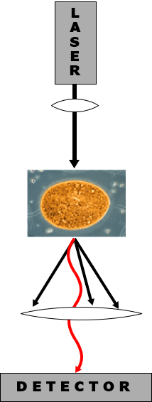

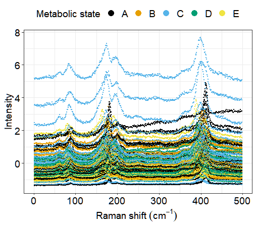

- Predicting metabolic state from standardized scatter intensities
- Comparing linear methods to non-linear methods for the task

## Support Vector Machines with Radial Kernel

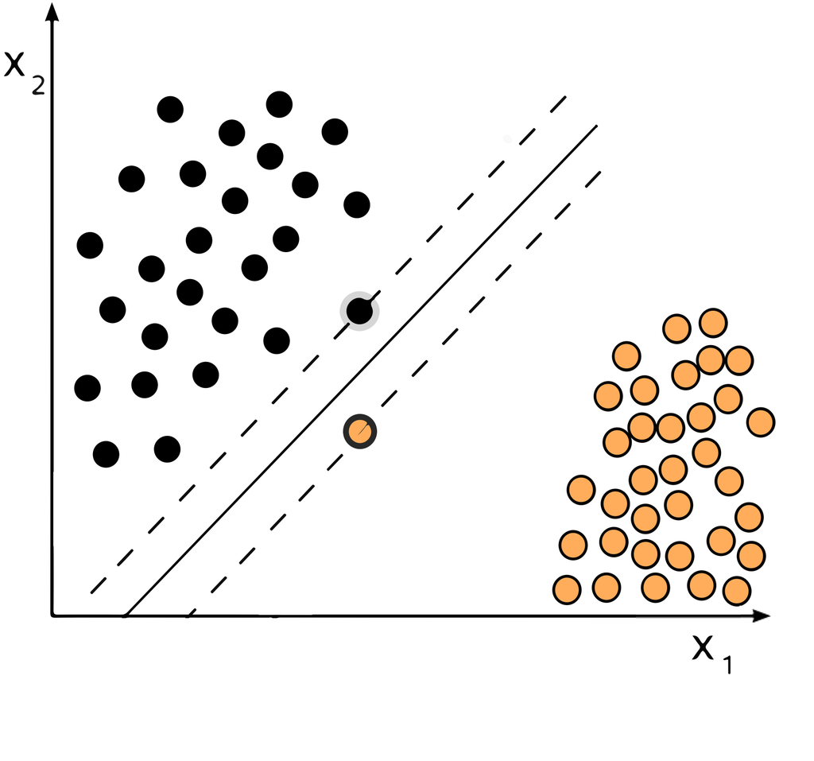

- non-probabilistic
- maximises the **margin**

\[ \begin{array}{l}{\underset{\boldsymbol{\alpha}}{\operatorname{argmax}} \sum_{n} \alpha_{n}-\frac{1}{2} \sum_{n, m} \alpha_{n} \alpha_{m} y_{n} y_{m} \mathbf{x}_{n}^{\top} \mathbf{x}_{m}} \\ {\text { with constraint: } \sum_{n=1}^{N} \alpha_{n} y_{n}=0, \quad 0 \leq \alpha_{n} \leq C} \end{array} \]

## What if there is no linear hyperplane that separates the data?

\[ \underset{\boldsymbol{\alpha}}{\operatorname{argmax}} \sum_{n} \alpha_{n}-\frac{1}{2} \sum_{n, m} \alpha_{n} \alpha_{m} y_{n} y_{m} K\left(\mathbf{x}_{n}, \mathbf{x}_{m}\right) \]

Kernels:

- Polynomial
- Radial: \(K\left(\mathbf{x}_{n}, \mathbf{x}_{m}\right)=\exp \left\{-\gamma\left(\mathbf{x}_{n}-\mathbf{x}_{m}\right)^{\top}\left(\mathbf{x}_{n}-\mathbf{x}_{m}\right)\right\}\), where \(\gamma\) is a hyperparameter which controls the complexity of the decision boundary

## GLMs for Logistic Regression

- a systematic component, the linear combination of predictors and parameters \(\mathbf \theta^\top x\)
- a random component, which defines the distributions of the outcomes
- a link function, so that \(\mathbb{E}(Y) = g^{-1}(\mathbf \theta^\top x).\)

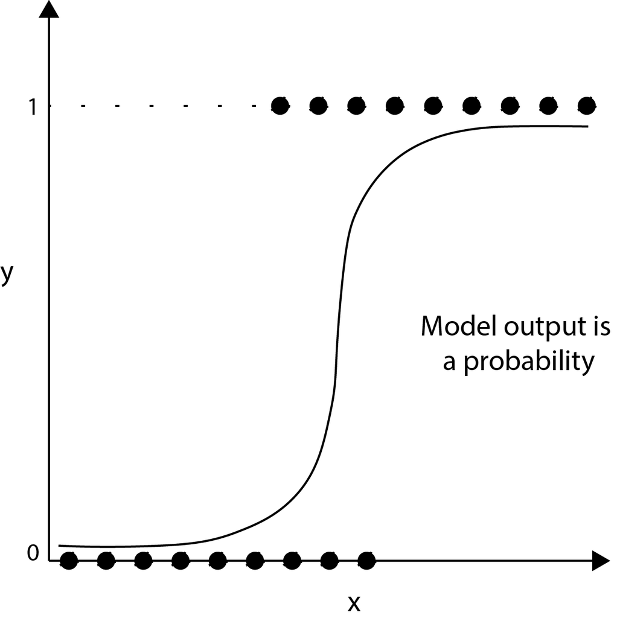

## Regularized Logistic Regression

\[ \mathrm{h}_{\theta}(x) = P(Y=1 | \mathbf{x} ; \theta) =g^{-1}\left(\theta^{T} \mathbf{x}\right)=\frac{1}{1+e^{-\theta^{T} \mathbf{x}}} \]

To find the parameters: \[ \min_{\theta}J(\theta)=-y \log \left(h_{\theta}(\mathbf{x})\right)-(1-y) \log \left(1-h_{\theta}(\mathbf{x})\right) \]

For multiple classes: \[ P(Y=k | \mathbf{x} ; \theta)=\frac{e^{-\theta_{k}^{T} \mathbf{x}}}{\sum_{k=1}^{K} e^{-\theta^{T} \mathbf{x}}} \]

## Elastic Net

Elastic net penalized the regression coefficients based on both the \(L_1\) norm and the \(L_2\) norm: \[\min_{\theta}J(\theta) +\lambda_{1} \sum_{j=1}^{n_{P}}\left|\theta_{j}\right|+\lambda_{2} \sum_{j=1}^{n_{P}} \theta_{j}^{2}\]

\(L_1\) (LASSO):

- Sparsity
- Only one amongst many correlated variables is selected

\(L_2\) (Ridge):

- Grouped selection
- It works well with multicollinear variables

## Nested Cross-validation

Models depend on hyperparameter choice to trade off the misclassification error against cost minimization.

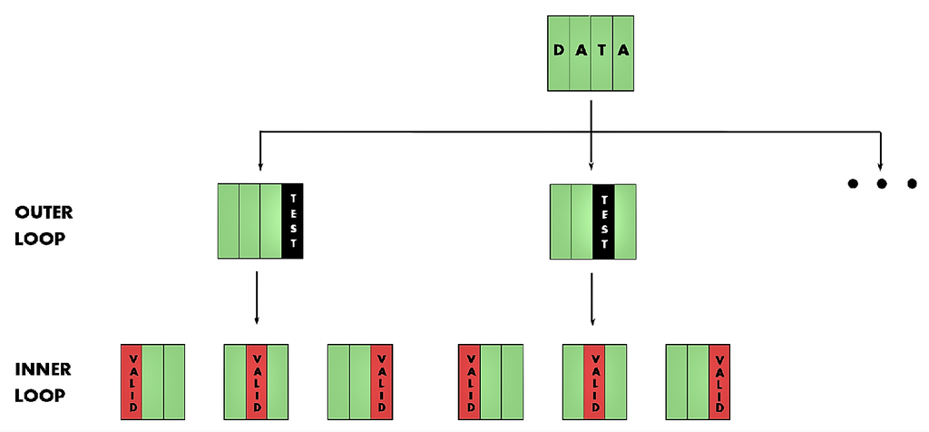

To compare models, the resampling strategy MUST be the same.

## Kappa

Accuracy can be problematic when the classes are unbalanced. Accuracy is threshold dependent.

\[ \text{Kappa}=\frac{\text {Total Accuracy}-\text {Random Accuracy}}{1-\text {Random Accuracy}} \]

Pros:

- Normalized so we can compare performance of two algorithms on the same classification task
- Tables can give an approximate idea of how well a value of Kappa is

Cons:

- Threshold dependent just like accuracy

**Ideal to use Brier score but resource intensive**

## Results

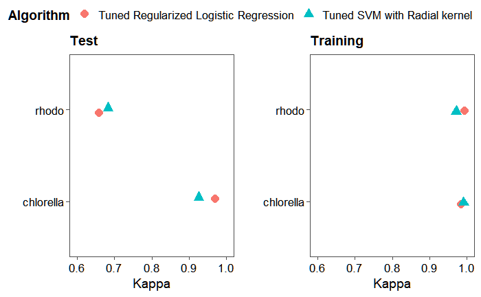

| Algorithm | Mean Test Kappa | Mean Training Kappa |
| --- | --- | --- |
| **Chlorella** |  |  |
| Tuned GLM elastic net | 0.970 | 0.984 |
| Tuned SVM with Radial Kernel | 0.926 | 0.991 |
| **Rhodo** |  |  |
| Tuned GLM elastic net | 0.660 | 0.994 |
| Tuned SVM with Radial Kernel | 0.683 | 0.971 |

## Hypothesis Testing

- Parametric requires assumption of normality
- Non-parametric does not allow us to reject \(H_0\), but have little power
- Bayesian hierarchical modelling

|  | KSVM.is.better | Equivalence | GLM.is.better |
| --- | --- | --- | --- |
| Chlorella | 0.054 | 0.10375 | 0.84225 |
| Rhodo | 0.486 | 0.13675 | 0.37725 |

## Summary

- **Data**: Raman shift and intensities + one categorical variable
- **Goal**: Compare linear methods with non-linear methods for this task
- **Algorithms**: Regularized logistic regression (linear) and Radial Support Vector Machines (non-linear)
- **Resampling**: Nested Cross-validation
- **Metric**: Kappa
- **Hypothesis testing**: Bayesian approach
- **Results**: GLM better on Chlorella and worse on Rhodo

## Advanced

- Pre-processing data with PCA before Logistic Regression
- Improving SVM by trying other kernels
- Random Forest (probabilistic)

## Additional: EDA

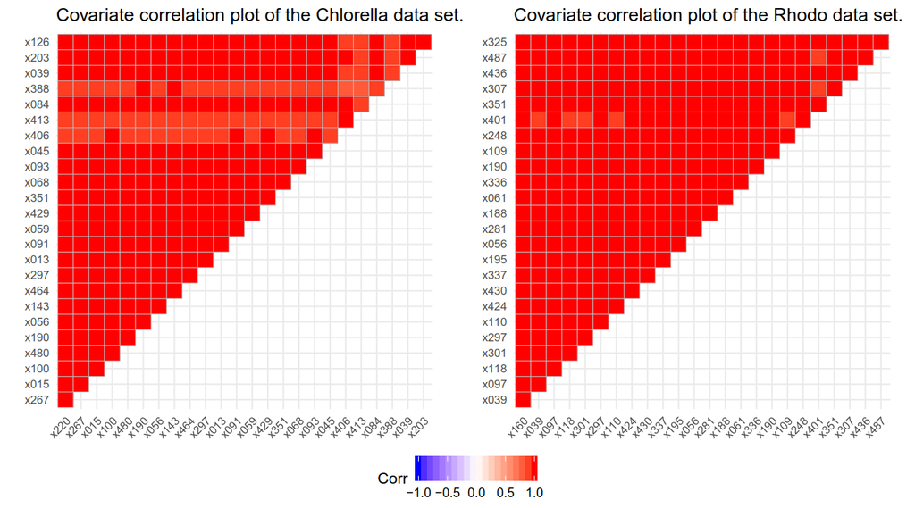

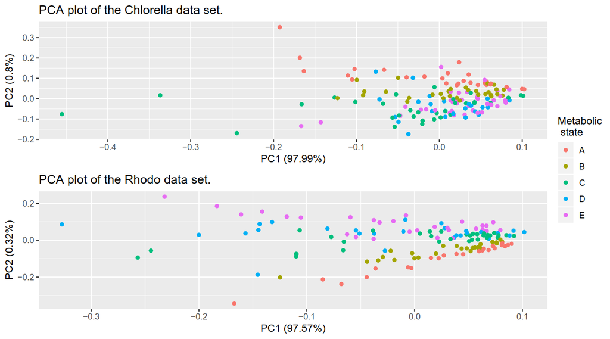

## Additional: Tuning

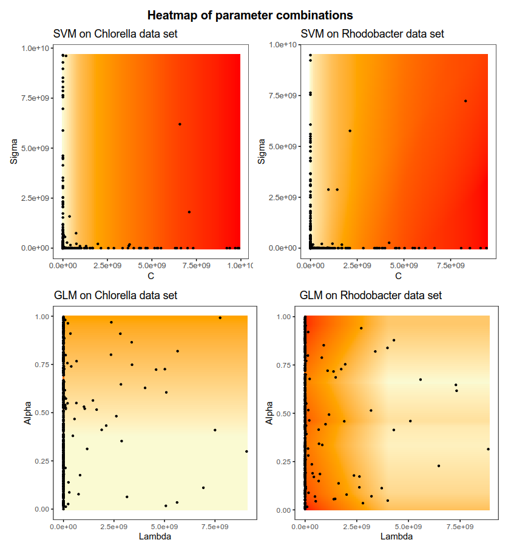

## Additional: Bayesian approach

\[ \begin{array}{l}{\mathbf{\delta_{i}} \sim M V N\left(\mathbf{1} \mu_{i}, \mathbf{\Sigma}_{\mathbf{i}}\right)} \\{\mu_{1}, \mu_{2} \sim t\left(\mu_{0}, \sigma_{0}, \nu\right)} \\ {\sigma_{1}, \sigma_{2} \sim \operatorname{unif}(0, 1000\overline{s})} \end{array}, \] where \(\overline{s}\) is the standard deviation of the \(\delta_i\)’s averaged on different data sets.

\[\begin{array}{l}{\mu_{0} \sim \operatorname{unif}(-1,1)} \\ {\sigma_{0} \sim \operatorname{unif}\left(0, 1000s_{\overline{\delta}}\right)} \\ {\nu \sim \operatorname{Gamma}(\alpha, \beta)} \\ {\alpha \sim \operatorname{unif}(0.5, 5)} \\ {\beta \sim \operatorname{unif}(0.05,0.15)}\end{array},\] where \(s_{\overline{\delta}}\) is the standard deviation of the \(\delta_i\)’s from one data set.

We define a region of practical equivalence (rope): (-0.01,0.01) We sample from the posterior distribution of \(\delta_i\) on both data sets. We record the number of times that \(\delta_\text{new}\) is smaller or greater than the rope. We calculate probabilities.

**Advantage**: \(\delta_i\)’s in one data set **borrow strength** from the \(\delta_i\)’s of another data set.